# R Notebook

# Explore different linkage methods

```r
# find clusters that minimise variance
alt_clusters <- diss_matrix %>%
  hclust(method = "ward.D2")

# get dendogram complete linkage
clustering_dendogram <- clusters_wo_scale %>%
  as.dendrogram() %>%
  dendextend::set("labels_cex", 0.5)

# dendogram variance method
alt_clustering_dendogram <- alt_clusters %>%
  as.dendrogram() %>%
  dendextend::set("labels_cex", 0.5)
```

Compare different clusters

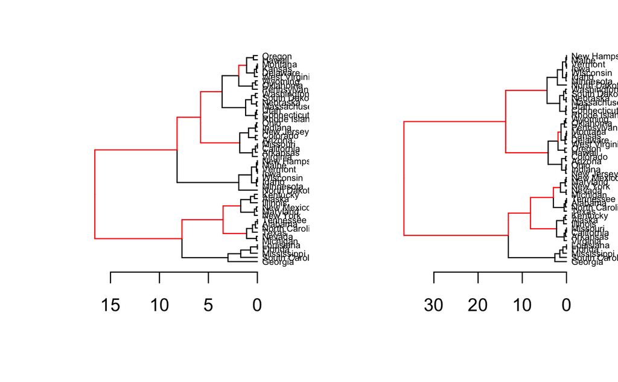

Interpretation and selection of clusters is context dependent.

# Plot clusters

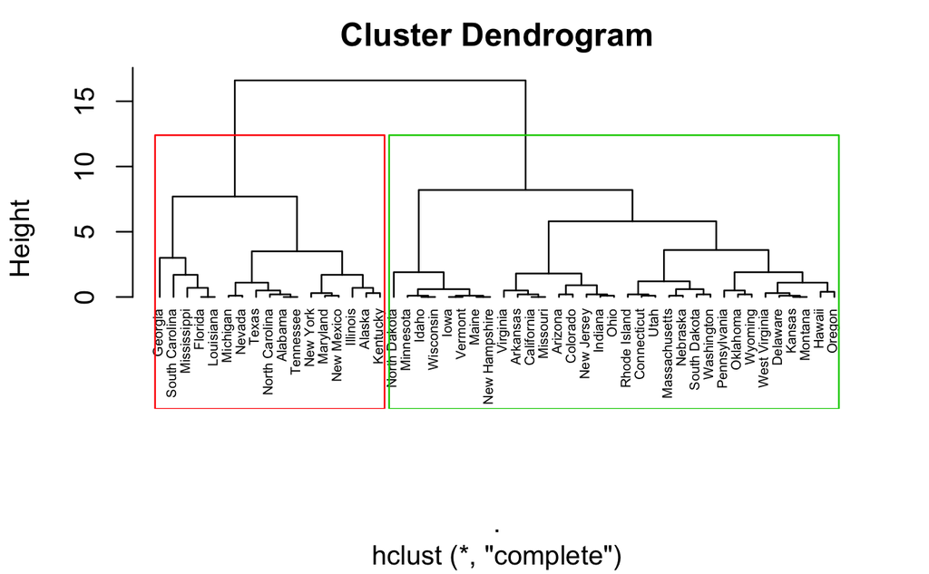

```r
plot(clusters_wo_scale, cex = 0.5, hang = -5)
rect.hclust(clusters_wo_scale, k = 2, border = 2:5)
```

Based on this analysis, we found 2 clusters of high school completion rates across states.

# Add which cluster a data point belongs to into data

| X1 | high_school | community_college | college | grad_school | high_school_cluster |
| --- | --- | --- | --- | --- | --- |
| Alabama | 13.2 | 236 | 58 | 21.2 | 1 |
| Alaska | 10.0 | 263 | 48 | 44.5 | 1 |
| Arizona | 8.1 | 294 | 80 | 31.0 | 2 |
| Arkansas | 8.8 | 190 | 50 | 19.5 | 2 |
| California | 9.0 | 276 | 91 | 40.6 | 2 |
| Colorado | 7.9 | 204 | 78 | 38.7 | 2 |

# Task

Spend some time carrying out cluster analysis for your other variables community_college, college, and grad_school. What do you find for each variable? How many clusters do you choose, and why? What are your interpretations from your analysis? What happens if you include all your data and perform clustering? (i.e. do not subset the data as we did in one of our first steps). For this, you have moved from predicting a specific variable to predicting something you might denoted as “overall education rates”. Do you get different results when the clustering takes into account all your data at once for each state? How would you interpret your results?